# Pertemuan 1 Pemulusan

Nadila Putri Fauziyyah

## Library / Packages

```r
library("forecast")
```

```r
library("graphics")
library("TTR")
library("TSA")
```

## Impor Data

```r
library(rio)
data1 <- import("https://raw.githubusercontent.com/nadilaputrif/MPDW-NadilaPF/main/Data/Data_suhu.csv")
```

## Eksplorasi Data

```r
View(data1)
str(data1)
```

```
## 'data.frame':    156 obs. of  2 variables:
##  $ Periode: int  1 2 3 4 5 6 7 8 9 10 ...
##  $ Suhu   : num  23.7 24.8 24.7 24.8 25 ...
```

```r
dim(data1)
```

```
## [1] 156   2
```

Mengubah data agar terbaca sebagai data deret waktu dengan fungsi `ts()` .

```r
data1.ts <- ts(data1$Suhu)
```

Menampilkan ringkasan data

```r
summary(data1.ts)
```

```
##    Min. 1st Qu.  Median    Mean 3rd Qu.    Max.
##   22.61   23.74   24.12   24.17   24.59   26.46
```

Membuat plot data deret waktu

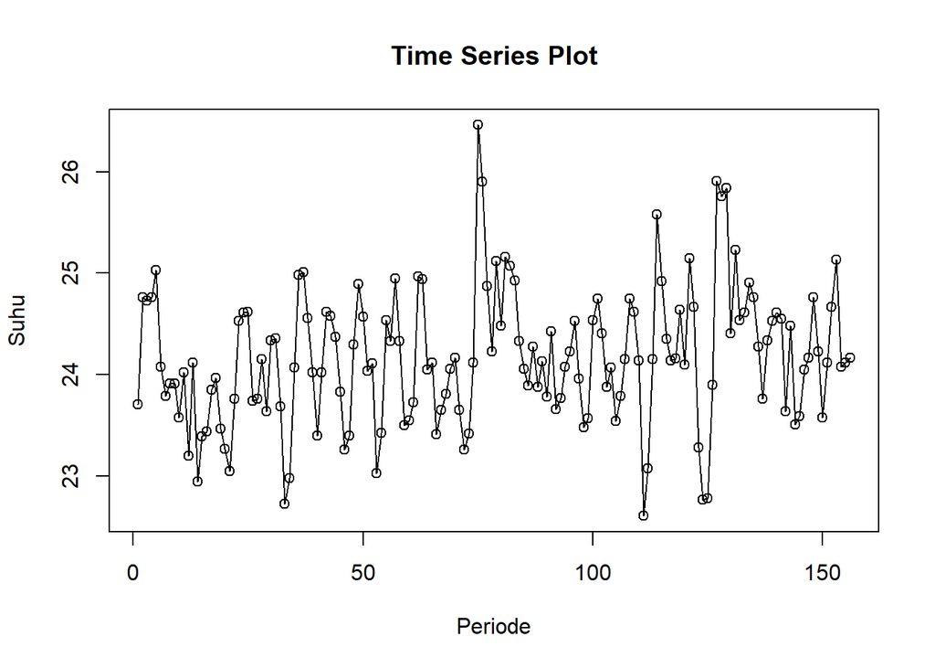

```r
ts.plot(data1.ts, xlab="Periode", ylab="Suhu",
        main = "Time Series Plot")
points(data1.ts)
```

## Single Moving Average & Double Moving Average

### Pembagian Data

Pembagian data latih dan data uji dilakukan dengan perbandingan 80% data latih dan 20% data uji.

```r
#membagi data latih dan data uji
training_ma <- data1[1:125,]
testing_ma <- data1[126:156,]
train_ma.ts <- ts(training_ma$Suhu)
test_ma.ts <- ts(testing_ma$Suhu)
```

### Eksplorasi Data

Eksplorasi data dilakukan pada keseluruhan data, data latih serta data uji menggunakan plot data deret waktu.

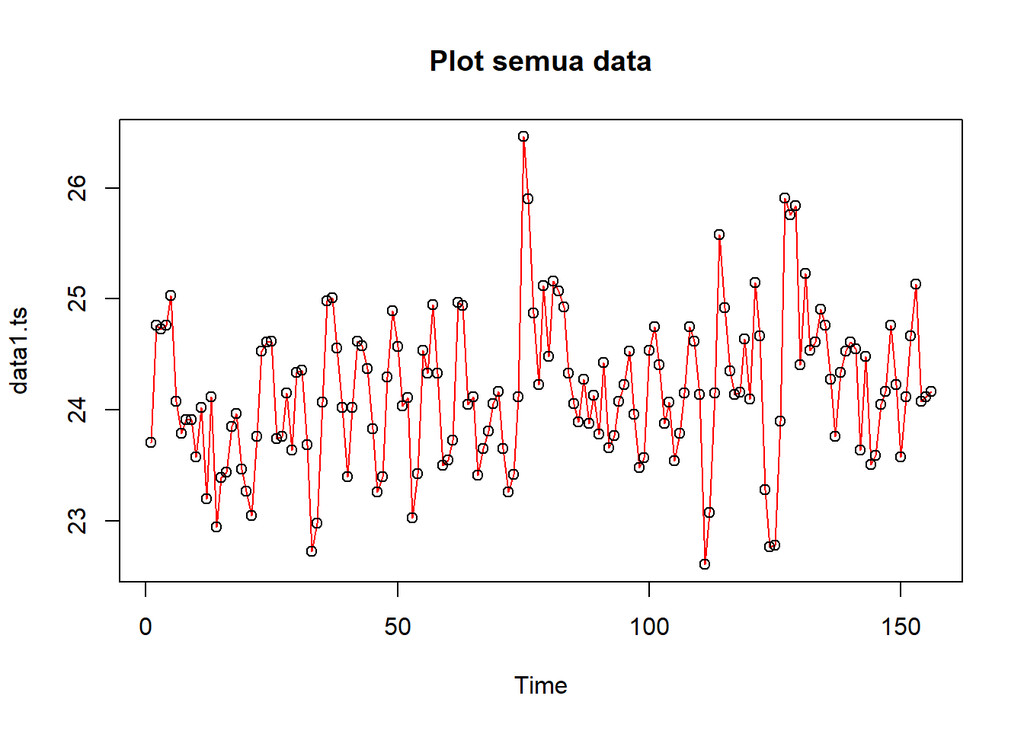

```r
#eksplorasi keseluruhan data
plot(data1.ts, col="red",main="Plot semua data")
points(data1.ts)
```

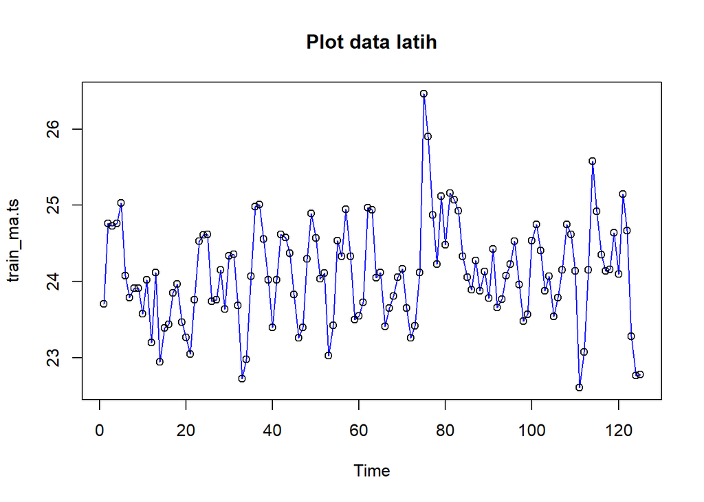

```r
#eksplorasi data latih
plot(train_ma.ts, col="blue",main="Plot data latih")
points(train_ma.ts)
```

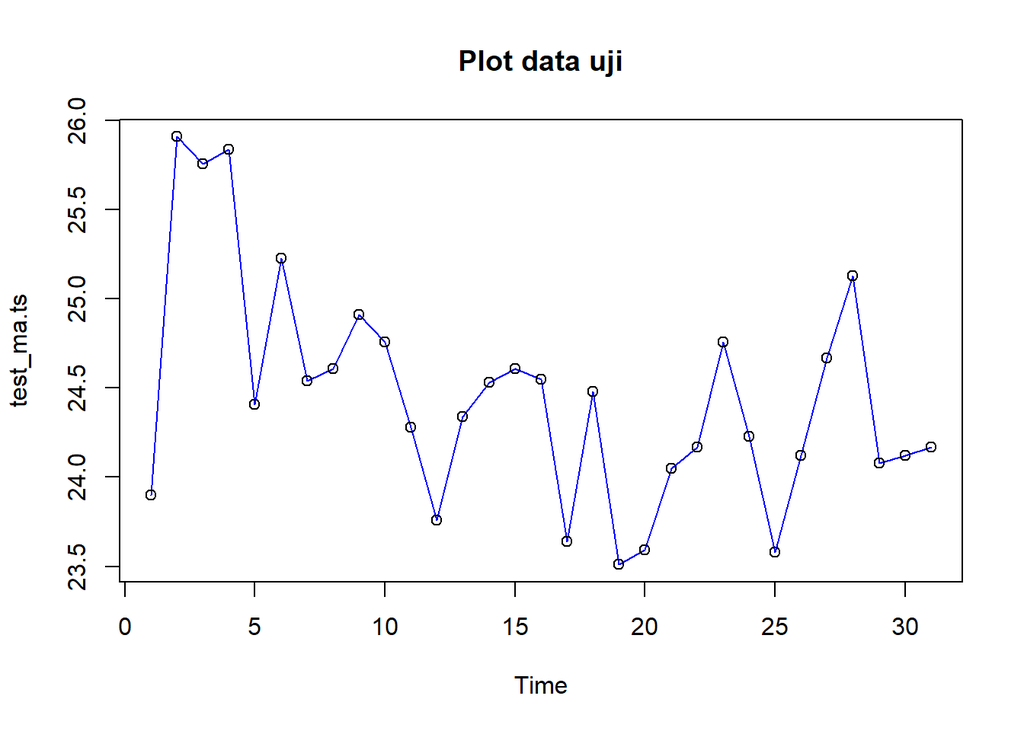

```r
#eksplorasi data uji
plot(test_ma.ts, col="blue",main="Plot data uji")
points(test_ma.ts)
```

Eksplorasi data juga dapat dilakukan menggunakan package `ggplot2` dengan terlebih dahulu memanggil library *package* `ggplot2`.

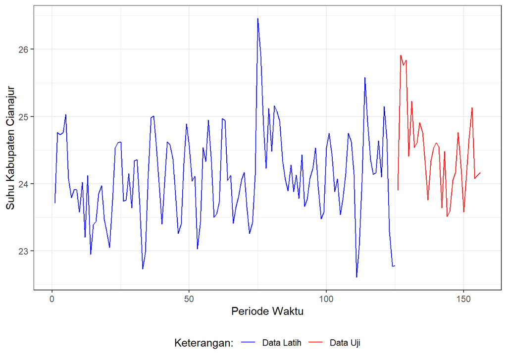

```r
#Eksplorasi dengan GGPLOT
library(ggplot2)
ggplot() +
  geom_line(data = training_ma, aes(x = Periode, y = Suhu, col = "Data Latih")) +
  geom_line(data = testing_ma, aes(x = Periode, y = Suhu, col = "Data Uji")) +
  labs(x = "Periode Waktu", y = "Suhu Kabupaten Cianajur", color = "Legend") +
  scale_colour_manual(name="Keterangan:", breaks = c("Data Latih", "Data Uji"),
                      values = c("blue", "red")) +
  theme_bw() + theme(legend.position = "bottom",
                     plot.caption = element_text(hjust=0.5, size=12))
```